# Weighted Avg & CCA

#### 2. Apply CCA to arctic pollen data

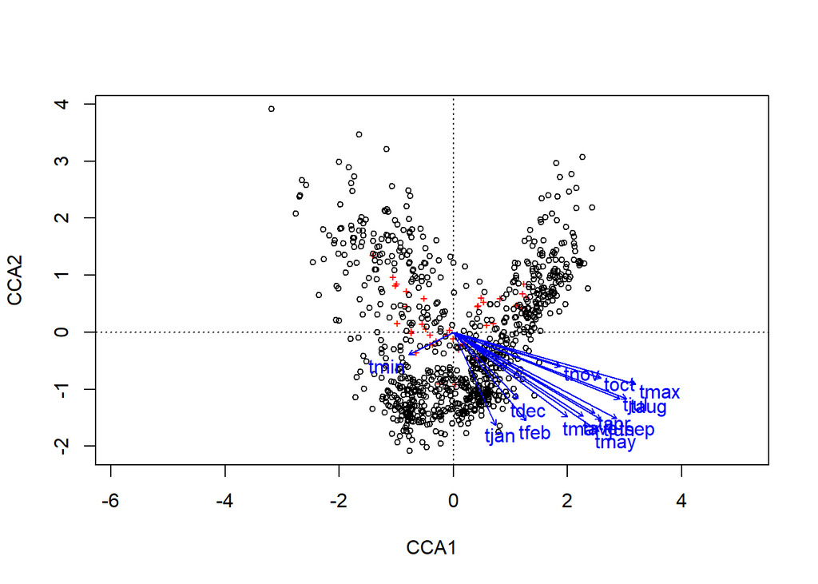

```r
data(arctic.pollen)
data(arctic.env)
arctic.ca <- cca(sqrt(arctic.pollen) ~ tave + tmax + tmin + tdec + tjan +tfeb + tmar + tapr + tmay + tjun + tjul + taug + tsep + toct + tnov + tdec.1, data = arctic.env)
plot(arctic.ca)
```

```r
head(summary(arctic.ca))
```

```
##
## Call:
## cca(formula = sqrt(arctic.pollen) ~ tave + tmax + tmin + tdec +      tjan + tfeb + tmar + tapr + tmay + tjun + tjul + taug + tsep +      toct + tnov + tdec.1, data = arctic.env)
##
## Partitioning of scaled Chi-square:
##               Inertia Proportion
## Total          1.1409     1.0000
## Constrained    0.4294     0.3764
## Unconstrained  0.7115     0.6236
##
## Eigenvalues, and their contribution to the scaled Chi-square
##
## Importance of components:
##                         CCA1    CCA2    CCA3    CCA4    CCA5     CCA6
## Eigenvalue            0.2118 0.09567 0.04469 0.02397 0.01836 0.009590
## Proportion Explained  0.1856 0.08385 0.03917 0.02101 0.01609 0.008405
## Cumulative Proportion 0.1856 0.26949 0.30866 0.32967 0.34576 0.354164
##                           CCA7     CCA8     CCA9    CCA10    CCA11
## Eigenvalue            0.007428 0.006698 0.003876 0.002279 0.001965
## Proportion Explained  0.006510 0.005870 0.003397 0.001998 0.001722
## Cumulative Proportion 0.360675 0.366545 0.369942 0.371940 0.373662
##                          CCA12     CCA13     CCA14     CCA15     CA1
## Eigenvalue            0.001148 0.0008917 0.0006785 0.0004002 0.05939
## Proportion Explained  0.001006 0.0007816 0.0005947 0.0003508 0.05205
## Cumulative Proportion 0.374668 0.3754492 0.3760438 0.3763946 0.42845
##                           CA2     CA3     CA4     CA5     CA6    CA7
## Eigenvalue            0.04434 0.03929 0.03257 0.03015 0.02973 0.0284
## Proportion Explained  0.03886 0.03444 0.02855 0.02642 0.02606 0.0249
## Cumulative Proportion 0.46731 0.50174 0.53030 0.55672 0.58278 0.6077
##                           CA8     CA9    CA10    CA11    CA12    CA13
## Eigenvalue            0.02740 0.02531 0.02334 0.02254 0.02117 0.02038
## Proportion Explained  0.02401 0.02219 0.02046 0.01976 0.01856 0.01786
## Cumulative Proportion 0.63169 0.65388 0.67434 0.69409 0.71265 0.73051
##                          CA14    CA15    CA16    CA17    CA18    CA19
## Eigenvalue            0.01931 0.01886 0.01764 0.01721 0.01647 0.01642
## Proportion Explained  0.01693 0.01653 0.01546 0.01508 0.01444 0.01439
## Cumulative Proportion 0.74744 0.76397 0.77943 0.79451 0.80895 0.82333
##                          CA20    CA21    CA22    CA23    CA24    CA25
## Eigenvalue            0.01537 0.01426 0.01419 0.01356 0.01292 0.01224
## Proportion Explained  0.01347 0.01250 0.01244 0.01189 0.01133 0.01073
```

[output cut: 73 more lines]

```
## tave  0.6346 -0.4108 -0.45242  0.29748 0.33102  0.013350
## tmax  0.8894 -0.2522  0.18188 -0.06362 0.15571 -0.084227
## tmin -0.2176 -0.1095 -0.63893  0.52593 0.14607 -0.004005
## tdec  0.3149 -0.3244 -0.63818  0.48481 0.20415  0.052528
## tjan  0.2055 -0.4547 -0.59431  0.48511 0.29125  0.025829
## tfeb  0.3552 -0.4318 -0.53038  0.40884 0.38441  0.087053
## tmar  0.5562 -0.4122 -0.42976  0.36336 0.38636  0.096877
## tapr  0.6909 -0.3967 -0.35401  0.19898 0.39978  0.111790
## tmay  0.7116 -0.4853 -0.17911  0.06833 0.44017  0.048803
## tjun  0.7187 -0.4257  0.09231 -0.08085 0.47923 -0.076572
## tjul  0.8111 -0.3252  0.07574 -0.07470 0.38227 -0.177912
## taug  0.8447 -0.3238 -0.10250  0.02373 0.33183 -0.200758
## tsep  0.7983 -0.4223 -0.29792  0.14299 0.20186 -0.141181
## toct  0.7193 -0.2219 -0.57109  0.21931 0.07823 -0.053236
## tnov  0.5213 -0.1668 -0.68246  0.41964 0.02252  0.050961
```

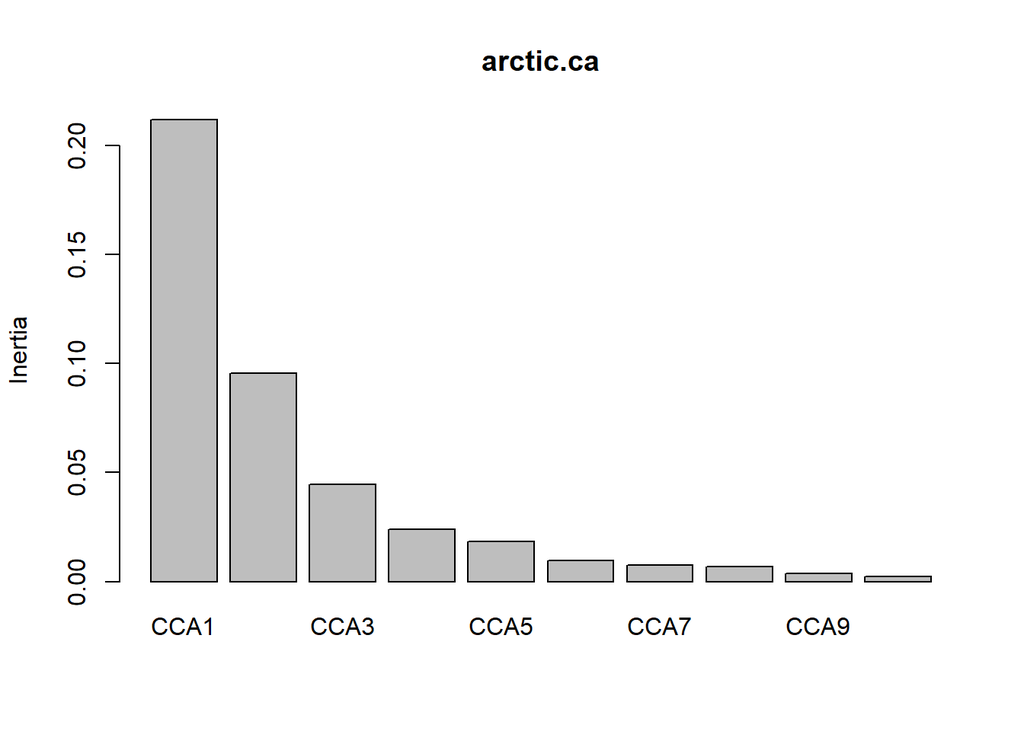

```r
screeplot(arctic.ca)
```

CCA1 explains 0.4932 of the variance, and tmax has the highest biplot score for that axis. Therefore, tmax appears to be the variable that explains more of the variance than the others included in the analysis.

```r
var.ex <- varpart(sqrt(arctic.pollen), arctic.env$tjul, arctic.env$tjan)
var.ex
```

```
##
## Partition of variance in RDA
##
## Call: varpart(Y = sqrt(arctic.pollen), X = arctic.env$tjul,
## arctic.env$tjan)
##
## Explanatory tables:
## X1:  arctic.env$tjul
## X2:  arctic.env$tjan
##
## No. of explanatory tables: 2
## Total variation (SS): 22419
##             Variance: 27.109
## No. of observations: 828
##
## Partition table:
##                      Df R.squared Adj.R.squared Testable
## [a+b] = X1            1   0.22897       0.22804     TRUE
## [b+c] = X2            1   0.03129       0.03012     TRUE
## [a+b+c] = X1+X2       2   0.27042       0.26865     TRUE
## Individual fractions
## [a] = X1|X2           1                 0.23853     TRUE
## [b]                   0                -0.01049    FALSE
## [c] = X2|X1           1                 0.04061     TRUE
## [d] = Residuals                         0.73135    FALSE
## ---
## Use function 'rda' to test significance of fractions of interest
```

Since a+b+c - a+b = c, 0.27042 - 0.22897 = 0.04145 (tjan).

And a+b+c - b+c = a, 0.27042 - 0.03129 = 0.23913 (tjul).

So, January and July temperatures explain roughly 0.04145 and 0.23913 of the variance, respectively.

**Constrain the arctic pollen dataset using tjan, tjul, ptotal, and sjul**

```r
colnames(arctic.env)
```

```
##   [1] "ID2"         "ID1"         "BIOME"       "New.Obsname" "Region"
##   [6] "Longitude"   "Latitude"    "Elevation"   "tave"        "tmax"
##  [11] "tmin"        "tdec"        "tjan"        "tfeb"        "tmar"
##  [16] "tapr"        "tmay"        "tjun"        "tjul"        "taug"
##  [21] "tsep"        "toct"        "tnov"        "tdec.1"      "ptotal"
##  [26] "pjan"        "pfeb"        "pmar"        "papr"        "pmay"
##  [31] "pjun"        "pjul"        "paug"        "psep"        "poct"
##  [36] "pnov"        "pdec"        "sjan"        "sfeb"        "smar"
##  [41] "sapr"        "smay"        "sjun"        "sjul"        "saug"
##  [46] "ssep"        "soct"        "snov"        "sdec"        "gdd0"
##  [51] "gdd5"        "chill"       "mtco"        "mtwa"        "mipt"
##  [56] "aaetpt"      "apetpt"      "miptev"      "aaetptev"    "apetptev"
##  [61] "miptdc"      "aaetptdc"    "apetptdc"    "totsnopt"    "annp"
##  [66] "pjanpann"    "pjulpann"    "IGBP21"      "BATS21"      "GLEC21"
##  [71] "NASLC21"     "USGS21"      "SIB2_21"     "RUNN21"      "IGBP03"
##  [76] "IGBP11"      "IGBP51"      "IGBP101"     "NLAND"       "NPIX"
##  [81] "IGBP21_1"    "IGBP21_2"    "IGBP21_3"    "IGBP21_4"    "IGBP21_5"
##  [86] "IGBP21_6"    "IGBP21_7"    "IGBP21_8"    "IGBP21_9"    "IGBP21_21"
##  [91] "IGBP21_11"   "IGBP21_12"   "IGBP21_13"   "IGBP21_14"   "IGBP21_15"
##  [96] "IGBP21_16"   "IGBP21_17"   "NeedAvg03"   "NeedAvg11"   "NeedAvg51"
## [101] "NeedAvg101"  "BroadAvg03"  "BroadAvg11"  "BroadAvg51"  "BroadAvg101"
```

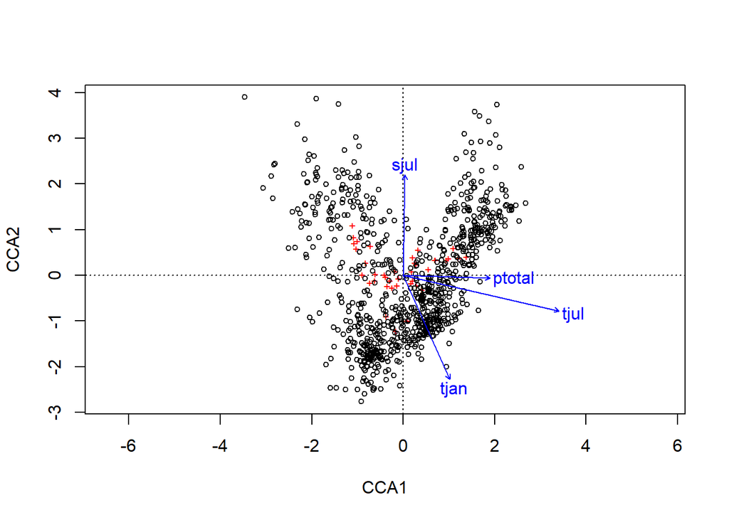

```r
new.ca <- cca(sqrt(arctic.pollen) ~ tjan + tjul + ptotal + sjul, data = arctic.env)
ordiplot(new.ca)
```

Annual precipitation and July temperatures appear to explain most of the variance, while July sunshine appears to essentially describe the variance in CCA2. Precipitation and July sunshine are almost completely orthogonal to each other, each of which very closely correlate to the first two axes of the ordination.

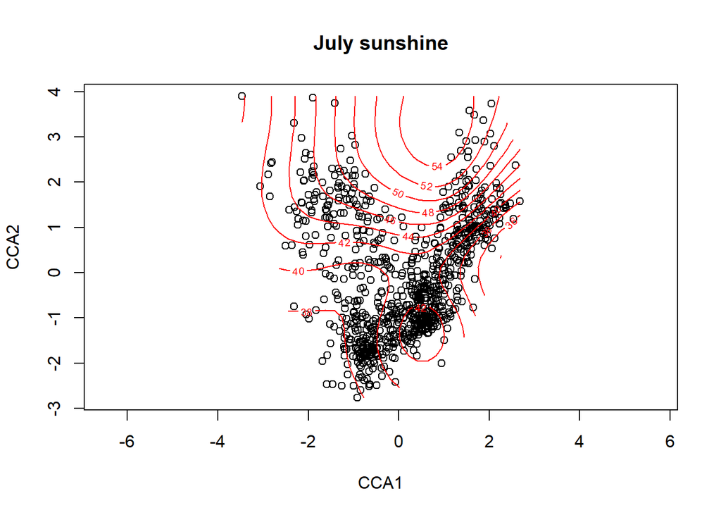

```
##
## Family: gaussian
## Link function: identity
##
## Formula:
## y ~ s(x1, x2, k = 10, bs = "tp", fx = FALSE)
##
## Estimated degrees of freedom:
## 8.55  total = 9.55
##
## REML score: 2395.364
```

```r
ordisurf(new.ca, arctic.env$sjul, main = "July sunshine")
```

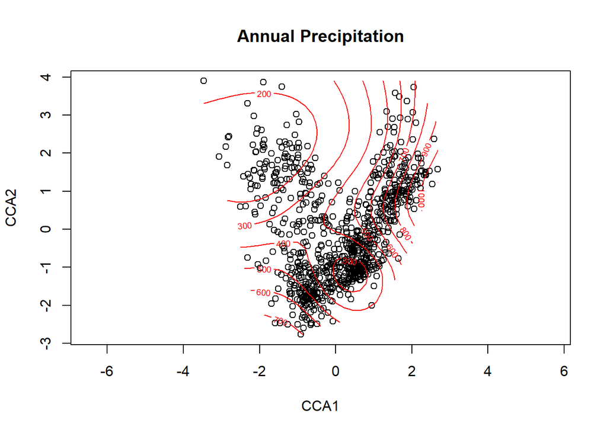

```
##
## Family: gaussian
## Link function: identity
##
## Formula:
## y ~ s(x1, x2, k = 10, bs = "tp", fx = FALSE)
##
## Estimated degrees of freedom:
## 8.5  total = 9.5
##
## REML score: 5803.674
```

```r
ordisurf(new.ca, arctic.env$ptotal, main = "Annual Precipitation")
```

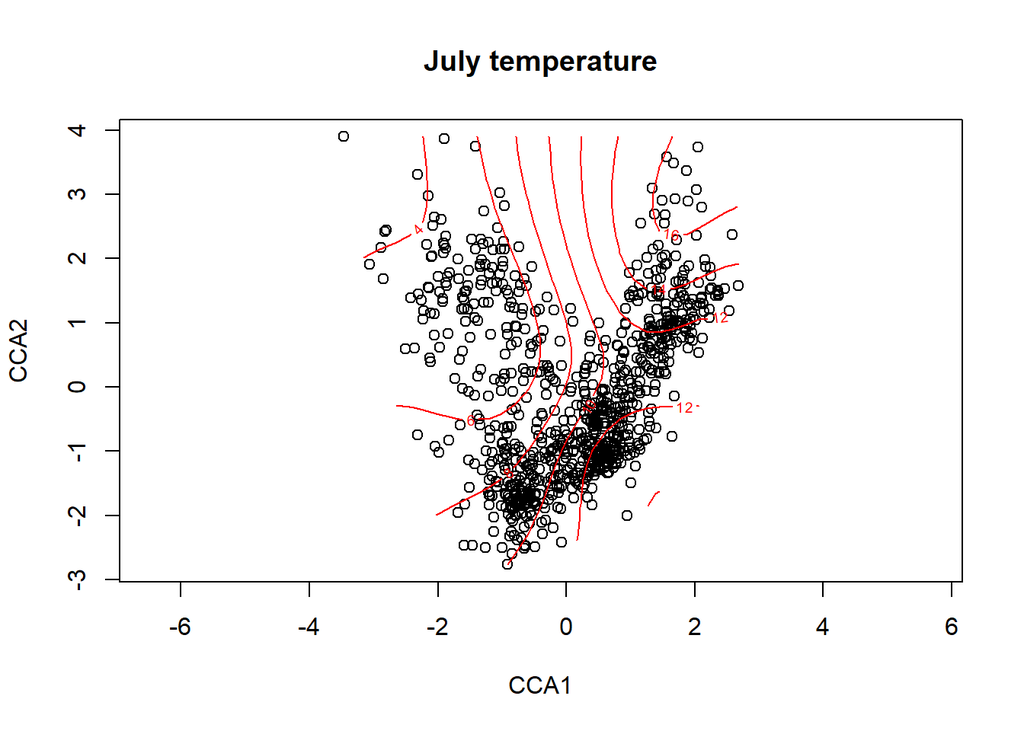

```
##
## Family: gaussian
## Link function: identity
##
## Formula:
## y ~ s(x1, x2, k = 10, bs = "tp", fx = FALSE)
##
## Estimated degrees of freedom:
## 8.84  total = 9.84
##
## REML score: 1699.555
```

```r
ordisurf(new.ca, arctic.env$tjul, main = "July temperature")
```

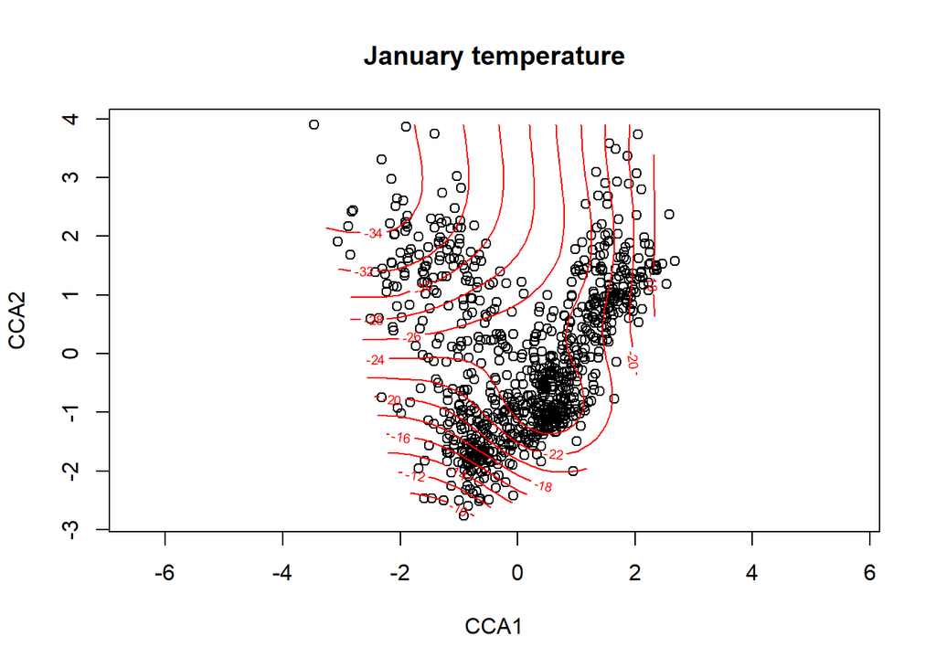

```
##
## Family: gaussian
## Link function: identity
##
## Formula:
## y ~ s(x1, x2, k = 10, bs = "tp", fx = FALSE)
##
## Estimated degrees of freedom:
## 8.58  total = 9.58
##
## REML score: 2522.47
```

```r
ordisurf(new.ca, arctic.env$tjan, main = "January temperature")
```

F.CYPE, F.BBET, F.PPIC,F.PPIN

#### 3. Weighted Averaging

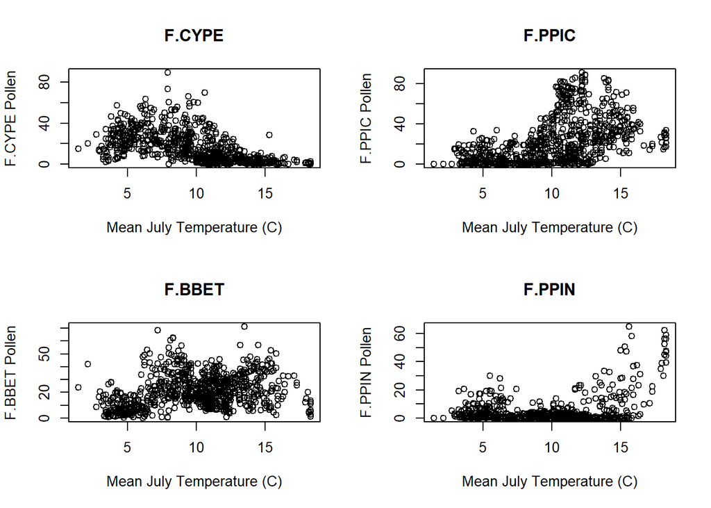

```r
layout(matrix(c(1,2,3,4), ncol = 2))
plot(arctic.pollen$F.CYPE ~ arctic.env$tjul, main = "F.CYPE", xlab = "Mean July Temperature (C)", ylab = "F.CYPE Pollen")
plot(arctic.pollen$F.BBET ~ arctic.env$tjul, main = "F.BBET", xlab = "Mean July Temperature (C)", ylab = "F.BBET Pollen")
plot(arctic.pollen$F.PPIC ~ arctic.env$tjul, main = "F.PPIC", xlab = "Mean July Temperature (C)", ylab = "F.PPIC Pollen")
plot(arctic.pollen$F.PPIN ~ arctic.env$tjul, main = "F.PPIN", xlab = "Mean July Temperature (C)", ylab = "F.PPIN Pollen")
```

```r
taxa <- data.frame(arctic.pollen$F.CYPE, arctic.pollen$F.PPIC, arctic.pollen$F.BBET, arctic.pollen$F.PPIN)
colnames(taxa) <- c("f.cype", "f.ppic", "f.bbet", "f.ppin")
wa.opt <- analogue::optima(taxa, arctic.env$tjul)
wa.opt #Species optima (for July temp)
```

```
##
##  Weighted Average Optima For: arctic.env$tjul
##
##    f.cype    f.ppic    f.bbet    f.ppin
##  7.963289 11.690868 10.514626 12.108539
```

```r
wa.tol <- tolerance(taxa, arctic.env$tjul)
wa.tol #Species tolerance (for July temp)
```

```
##
##  Weighted Average Tolerances For: arctic.env$tjul
##
##   f.cype   f.ppic   f.bbet   f.ppin
## 2.807172 2.819576 3.127384 4.936146
```

Add unimodal response approximated by weighted averaging to the abundance plots.

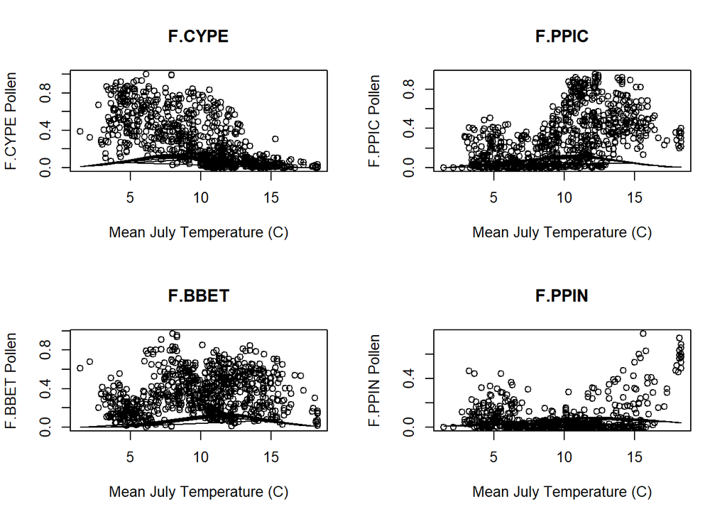

```r
taxa.prop <- taxa/rowSums(taxa)
layout(matrix(c(1,2,3,4), ncol = 2))
plot(taxa.prop$f.cype ~ arctic.env$tjul, main = "F.CYPE", xlab = "Mean July Temperature (C)", ylab = "F.CYPE Pollen")
lines(arctic.env$tjul, dnorm(arctic.env$tjul, 7.963289, 2.807172))
plot(taxa.prop$f.bbet ~ arctic.env$tjul, main = "F.BBET", xlab = "Mean July Temperature (C)", ylab = "F.BBET Pollen")
lines(arctic.env$tjul, dnorm(arctic.env$tjul, 11.690868, 2.819576))
plot(taxa.prop$f.ppic ~ arctic.env$tjul, main = "F.PPIC", xlab = "Mean July Temperature (C)", ylab = "F.PPIC Pollen")
lines(arctic.env$tjul, dnorm(arctic.env$tjul, 10.514626, 3.127384))
plot(taxa.prop$f.ppin ~ arctic.env$tjul, main = "F.PPIN", xlab = "Mean July Temperature (C)", ylab = "F.PPIN Pollen")
lines(arctic.env$tjul, dnorm(arctic.env$tjul, 12.108539, 4.936146))
```

Estimate July temperature optima for all taxa in the arctic.pollen dataset and compare them to species scores in CA

```r
colnames(arctic.pollen) #Let's see which taxa we have
```

```
##  [1] "F.PABI" "F.BALN" "F.CAMB" "F.APIA" "F.CART" "F.TULI" "F.BBET"
##  [8] "F.BRAS" "F.CARY" "F.CHEN" "F.BCOR" "F.CUPR" "F.CYPE" "F.RDRY"
## [15] "F.ELAE" "F.ERIC" "F.FABA" "F.FFAG" "F.OFRA" "F.PLAR" "F.MMYR"
## [22] "F.ONAG" "F.POXR" "F.PAPA" "F.PPIC" "F.PPIN" "F.PPLA" "F.POAC"
## [29] "F.POLE" "F.POLY" "F.SPOP" "F.FQUE" "F.RANU" "F.ROSA" "F.SSAL"
## [36] "F.SAXI" "F.SCRO" "F.RTHA" "F.ULMA"
```

```r
all.wa <- rioja::WA(arctic.pollen, arctic.env$tjul)
summary(all.wa) #Using function WA in rioja package
```

```
##
## Method : Weighted Averaging
## Call   : rioja::WA(y = arctic.pollen, x = arctic.env$tjul)
##
## Tolerance DW       : No
## Monotonic deshrink : No
## No. samples        : 828
## No. species        : 39
## Cross val.         : none
##
## Deshrinking regression coefficients:
##       Inverse d/s Classical d/s
## wa.b0    -13.8076        7.4381
## wa.b1      2.3929        0.2497
##
## Performance:
##           RMSE      R2  Avg.Bias  Max.Bias    Skill
## WA.inv  2.2475  0.5974         0    4.9551  59.7399
## WA.cla  2.9079  0.5974         0    3.2987  32.6077
##
##
## Fitted values
##        WA.inv    WA.cla
## 1   10.498622 10.893339
## 2    7.354684  5.630628
## 3    8.580845  7.683128
## .           .         .
## .           .         .
## 831  9.000520  8.385630
##
## Species coefficients
##           Optima
## F.PABI 12.475966
## F.BALN 10.818821
## F.CAMB  9.084608
## .              .
## .              .
## F.ULMA 13.437480
```

```r
coefficients(all.wa) #Species optima
```

```
##           Optima
## F.PABI 12.475966
## F.BALN 10.818821
## F.CAMB  9.084608
## F.APIA 10.827811
## F.CART  8.477746
## F.TULI  9.183194
## F.BBET 10.514626
## F.BRAS  5.328966
## F.CARY  5.732069
## F.CHEN 10.614274
## F.BCOR 11.721932
## F.CUPR  9.757364
## F.CYPE  7.963289
## F.RDRY  5.172128
## F.ELAE 10.916842
## F.ERIC  7.807915
## F.FABA  6.771484
## F.FFAG 13.296937
## F.OFRA 11.410076
## F.PLAR 11.989714
## F.MMYR 12.824865
## F.ONAG  8.804730
## F.POXR  4.795425
## F.PAPA  4.277656
## F.PPIC 11.690868
## F.PPIN 12.108539
## F.PPLA  6.668685
## F.POAC  8.222307
## F.POLE 12.576258
## F.POLY  6.683071
## F.SPOP 12.000761
## F.FQUE 13.332343
## F.RANU  7.172590
## F.ROSA  8.085031
## F.SSAL  6.927505
## F.SAXI  5.079544
## F.SCRO  5.991950
## F.RTHA  8.102166
## F.ULMA 13.437480
```

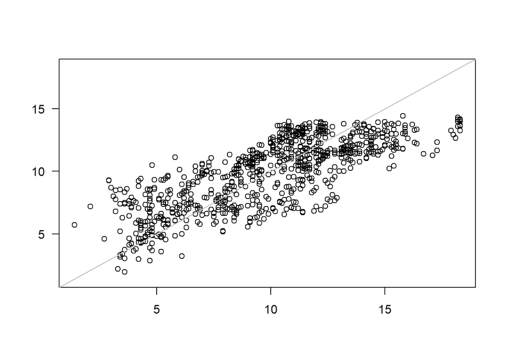

```r
all.wa.cal <- rioja::crossval(all.wa, verbose = FALSE, cv.method = "loo")
plot(all.wa.cal)
```

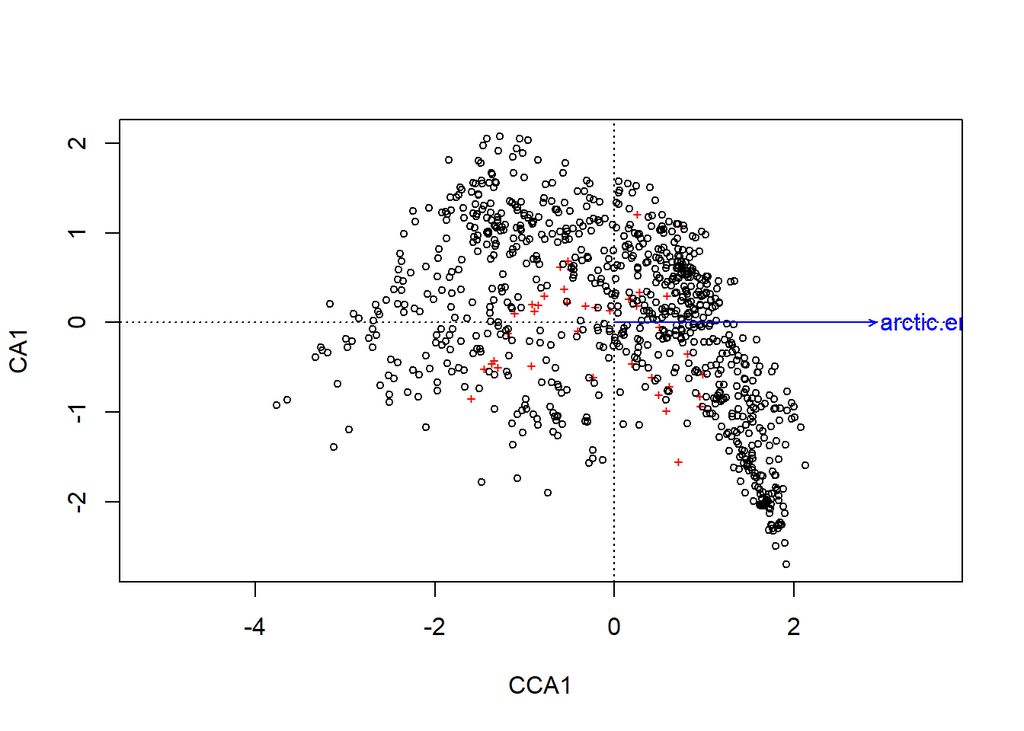

```r
#CCA for tjul
all.cca <- cca(arctic.pollen ~ arctic.env$tjul)
plot(all.cca)
```

```r
summary(all.cca)
```

```
##
## Call:
## cca(formula = arctic.pollen ~ arctic.env$tjul)
##
## Partitioning of scaled Chi-square:
##               Inertia Proportion
## Total          1.6587     1.0000
## Constrained    0.2497     0.1505
## Unconstrained  1.4091     0.8495
##
## Eigenvalues, and their contribution to the scaled Chi-square
##
## Importance of components:
##                         CCA1    CA1    CA2     CA3     CA4     CA5     CA6
## Eigenvalue            0.2497 0.2635 0.2268 0.13429 0.13016 0.10695 0.06921
```

[output cut: 1753 more lines]

I wrote the species scores above into a csv file so I could more easily work with it.

```r
spp.scores <- read.csv("species.scores.csv")
comp <- cbind(all.wa$coefficients,spp.scores[,2:6])
comp
```

```
##           Optima    CCA1      CA1     CA2      CA3      CA4
## F.PABI 12.475966  0.7236 -1.54401 -0.2530  0.31094 -0.99631
## F.BALN 10.818821  0.2558  0.19691 -0.3599 -0.15369  0.52828
## F.CAMB  9.084608 -0.2338 -0.60040  0.3139  0.59960  0.22010
## F.APIA 10.827811  0.2583  1.21128  0.2179 -0.73709 -0.72341
## F.CART  8.477746 -0.4052 -0.08401  0.2627  0.07157  0.47139
## F.TULI  9.183194 -0.2060  0.17705  0.1059  0.01500  0.04558
## F.BBET 10.514626  0.1699  0.27164 -0.2528  0.05214  0.12495
## F.BRAS  5.328966 -1.2941 -0.49231  0.5014 -1.15934  0.13091
## F.CARY  5.732069 -1.1803 -0.11088  0.5978 -0.69228 -0.24906
## F.CHEN 10.614274  0.1980 -0.45031  0.9261  0.22262  0.33628
## F.BCOR 11.721932  0.5107 -0.04694  1.0908 -0.07527  0.25382
## F.CUPR  9.757364 -0.0439  0.14087 -0.3149  0.01592  0.16158
## F.CYPE  7.963289 -0.5504  0.38020  0.1901  0.27934 -0.12157
## F.RDRY  5.172128 -1.3384 -0.41925  0.7957 -1.10615 -0.02614
## F.ELAE 10.916842  0.2834  0.34815 -0.6223 -0.20993  0.68767
## F.ERIC  7.807915 -0.5943  0.62692  0.2820  0.76582 -0.56848
## F.FABA  6.771484 -0.8869  0.13387  0.4514  0.32709 -0.05779
## F.FFAG 13.296937  0.9554 -0.81215 -0.3163  0.03630 -0.73397
## F.OFRA 11.410076  0.4227 -0.60134  0.7054  0.36382 -0.14830
## F.PLAR 11.989714  0.5863 -0.97612  0.1783  0.34636 -0.01912
## F.MMYR 12.824865  0.8221 -0.34092  0.1848 -0.03140  0.15270
## F.ONAG  8.804730 -0.3128  0.19339  0.2367  0.14339  0.04113
## F.POXR  4.795425 -1.4447 -0.50937  0.7074 -1.76301 -0.03779
## F.PAPA  4.277656 -1.5909 -0.84017  1.2939 -1.79000  0.19076
## F.PPIC 11.690868  0.5020 -0.79745 -0.3002  0.06949 -0.23196
## F.PPIN 12.108539  0.6199 -0.70731  1.7864  0.36161  0.68809
## F.PPLA  6.668685 -0.9159 -0.47737  0.2830 -0.93093  0.25829
## F.POAC  8.222307 -0.4773  0.59981  0.3058 -0.45062 -0.52570
## F.POLE 12.576258  0.7519  1.08541 -0.3768 -0.75429  0.23083
## F.POLY  6.683071 -0.9118  0.21420  0.5430  0.17154 -0.33511
## F.SPOP 12.000761  0.5894  0.30211 -0.2121 -0.26490  0.20131
## F.FQUE 13.332343  0.9654 -0.92623  1.0699  0.24841  0.15289
## F.RANU  7.172590 -0.7736  0.30285  0.5189 -1.16105 -0.59100
## F.ROSA  8.085031 -0.5160  0.23040  0.3248 -0.50308 -0.03489
## F.SSAL  6.927505 -0.8428  0.20044  0.4496 -0.47400 -0.42613
## F.SAXI  5.079544 -1.3645 -0.45059  0.6901 -1.27312  0.01757
## F.SCRO  5.991950 -1.1069  0.11206  0.5517 -0.53322 -0.16312
## F.RTHA  8.102166 -0.5112  0.69520  0.5865 -1.46528 -1.29402
## F.ULMA 13.437480  0.9950 -0.56571  0.7535  0.14079  0.05270
```

```r
#Using analogue package, using all taxa (Just for fun)
all.opt <- analogue::optima(arctic.pollen, arctic.env$tjul)
all.opt #WA optima for all taxa in dataset
```

```
##
##  Weighted Average Optima For: arctic.env$tjul
##
##    F.PABI    F.BALN    F.CAMB    F.APIA    F.CART    F.TULI    F.BBET
## 12.475966 10.818821  9.084608 10.827811  8.477746  9.183194 10.514626
##    F.BRAS    F.CARY    F.CHEN    F.BCOR    F.CUPR    F.CYPE    F.RDRY
##  5.328966  5.732069 10.614274 11.721932  9.757364  7.963289  5.172128
##    F.ELAE    F.ERIC    F.FABA    F.FFAG    F.OFRA    F.PLAR    F.MMYR
## 10.916842  7.807915  6.771484 13.296937 11.410076 11.989714 12.824865
##    F.ONAG    F.POXR    F.PAPA    F.PPIC    F.PPIN    F.PPLA    F.POAC
##  8.804730  4.795425  4.277656 11.690868 12.108539  6.668685  8.222307
##    F.POLE    F.POLY    F.SPOP    F.FQUE    F.RANU    F.ROSA    F.SSAL
## 12.576258  6.683071 12.000761 13.332343  7.172590  8.085031  6.927505
##    F.SAXI    F.SCRO    F.RTHA    F.ULMA
##  5.079544  5.991950  8.102166 13.437480
```

```r
all.tol <- tolerance(arctic.pollen, arctic.env$tjul)
all.tol #WA tolerance for all taxa in dataset
```

```
##
##  Weighted Average Tolerances For: arctic.env$tjul
##
##   F.PABI   F.BALN   F.CAMB   F.APIA   F.CART   F.TULI   F.BBET   F.BRAS
## 2.404492 2.921467 4.044970 2.702964 3.762606 3.305885 3.127384 2.018543
##   F.CARY   F.CHEN   F.BCOR   F.CUPR   F.CYPE   F.RDRY   F.ELAE   F.ERIC
## 2.532545 4.892700 5.416649 2.624345 2.807172 1.634831 2.689331 2.833859
##   F.FABA   F.FFAG   F.OFRA   F.PLAR   F.MMYR   F.ONAG   F.POXR   F.PAPA
## 2.936533 1.843614 4.251565 3.115744 2.840524 3.359176 1.700455 1.313141
##   F.PPIC   F.PPIN   F.PPLA   F.POAC   F.POLE   F.POLY   F.SPOP   F.FQUE
## 2.819576 4.936146 2.953938 3.286141 1.946416 2.755003 3.068541 3.764265
##   F.RANU   F.ROSA   F.SSAL   F.SAXI   F.SCRO   F.RTHA   F.ULMA
## 3.222232 3.475706 3.278609 1.625559 2.186664 3.395943 3.586704
```

```r
#Looks like we get the same results
```

**Predict July temperatures and compare them to CCA site scores.**

(I’m assuming we use our WA model to then predict July temperatures from the same species assemblages used to construct our model for this part of the assignment).

Let’s take a look at our predictions and compare them to the site scores.

```r
all.wa.mono <- rioja::WA(arctic.pollen, arctic.env$tjul, mono = TRUE) #Using all deshrinking options including mono
all.pred.mono <- predict(all.wa.mono)
all.pred.mono #Predictions
```

```
##        WA.inv     WA.cla      WA.m
## 1   10.498622 10.8933386 10.109322
## 2    7.354684  5.6306280  7.548677
## 3    8.580845  7.6831282  7.744979
## 4    9.437938  9.1178356  8.583971
## 5    8.674162  7.8393336  7.795265
## 6    9.315723  8.9132566  8.424528
## 7    8.422855  7.4186647  7.688582
## 8    8.198938  7.0438442  7.655151
## 9    8.599581  7.7144899  7.754027
## 10   7.710842  6.2268102  7.642518
## 11   7.381361  5.6752837  7.561237
## 12   8.518721  7.5791366  7.718754
## 13   8.430062  7.4307290  7.690457
## 14   7.280656  5.5067111  7.508255
```

[output cut: 814 more lines]

I wrote site scores into a csv file and read them back in so I could more easily work with them.

```r
site.scores <- read.csv("site.txt", sep = "")
head(site.scores)
```

```
##        CCA1       CA1      CA2      CA3      CA4
## 1  0.276805 -1.142988 0.600911 1.268980 1.826943
## 2 -1.208931 -0.085606 0.594233 1.465799 0.271377
## 3 -0.629481 -1.265308 0.295846 1.503722 1.609220
## 4 -0.224444 -0.675517 0.334273 1.834140 1.123985
## 5 -0.585382 -0.144469 0.800854 1.571035 0.991954
## 6 -0.282199 -0.617093 1.214924 1.366532 1.653958
```

```r
head(all.pred.mono)
```

```
##      WA.inv    WA.cla      WA.m
## 1 10.498622 10.893339 10.109322
## 2  7.354684  5.630628  7.548677
## 3  8.580845  7.683128  7.744979
## 4  9.437938  9.117836  8.583971
## 5  8.674162  7.839334  7.795265
## 6  9.315723  8.913257  8.424528
```

The sites scores along CCA1 appear to have similar relative values (to each other) to the relative values of the site predictions from our transfer function.

**Compare apparent and cross-validated predictions of July temperatures**

```r
all.pred.cal <- rioja::crossval(all.wa.mono)
```

```
## Cross-validating:
##
```

```r
all.pred.mono.cal <- predict(all.pred.cal) #Cross validated predictions
all.pred.mono.cal #Cross-validated predictions
```

```
##        WA.inv     WA.cla      WA.m
## 1   10.498622 10.8933386 10.109322
## 2    7.354684  5.6306280  7.548677
## 3    8.580845  7.6831282  7.744979
## 4    9.437938  9.1178356  8.583971
## 5    8.674162  7.8393336  7.795265
## 6    9.315723  8.9132566  8.424528
## 7    8.422855  7.4186647  7.688582
## 8    8.198938  7.0438442  7.655151
## 9    8.599581  7.7144899  7.754027
## 10   7.710842  6.2268102  7.642518
## 11   7.381361  5.6752837  7.561237
## 12   8.518721  7.5791366  7.718754
## 13   8.430062  7.4307290  7.690457
## 14   7.280656  5.5067111  7.508255
```

[output cut: 814 more lines]

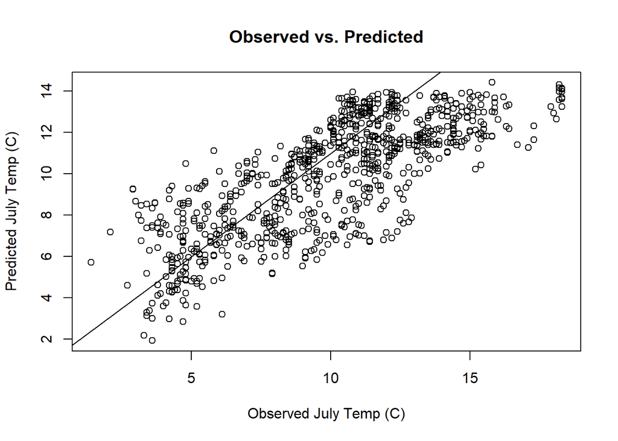

```r
#Compare apparent temperatures to cross-validated predictions
plot(all.pred.mono.cal[,1] ~ arctic.env$tjul, main = "Observed vs. Predicted", ylab = "Predicted July Temp (C)", xlab = "Observed July Temp (C)")
abline(1,1)
```

While the residuals between the observed temperatures and predicted values are quite large in certain instances, this model does appear to do an adequate job of predicting the July temperatures by using these species assemblages.